# Research Question

### This project will answer the research question: Does the daily closing price of bitcoin depend on the volume of bitcoin traded that day?

### The hypothesis that this project will investigate is: the volume of bitcoins traded daily will affect the final daily closing price. The null hypothesis in this case is, H<sub>0</sub> the final closing price of bitcoin does not depend on the volume of bitcoin trades that day. The alternative hypothesis, H<sub>a</sub> is that the final closing price does depend on the volume traded. The significance level for this project will be set at $\alpha$ = 0.05. (McNeese, 2020)

### Why study bitcoin? According to (Ullah, 2021) "The bitcoin market cap is over 1 trillion USD with 6350% growth from 2017"

### The phenomenal growth of the bitcoin market has made it a topic of great interest. People from all over the world have invested in bitcoin, and several banks and large companies are now heavily involved in the bitcoin market. Finding a factor that could potentially indicate which way the market will swing would be of great use.

# Step One: Install the Necessary Packages

```r
install.packages("corrplot")
```

```r
library(corrplot)
```

```r
install.packages("PerformanceAnalytics")
```

```r
library(PerformanceAnalytics)
```

```r
library(data.table)
```

```r
library(tidyverse)
```

```r
install.packages("caTools")
```

```r
install.packages("ROCR")
```

```r
library(caret)
```

```r
library(broom)
```

# Step Two: Import and Prepare the Data

### The data for this project comes from the website Kaggle.com (Bitcoin Historical Data, 2021)

### One challenge in acquiring the data was finding a source that had both closing price and daily trading volume in the same dataset.

### About the data: "Bitcoin is the longest running and most well known cryptocurrency, first released as open source in 2009 by the anonymous Satoshi Nakamoto. Bitcoin serves as a decentralized medium of digital exchange, with transactions verified and recorded in a public distributed ledger (the blockchain) without the need for a trusted record keeping authority or central intermediary. Transaction blocks contain a SHA-256 cryptographic hash of previous transaction blocks, and are thus "chained" together, serving as an immutable record of all transactions that have ever occurred. As with any currency/commodity on the market, bitcoin trading and financial instruments soon followed public adoption of bitcoin and continue to grow. Included here is historical bitcoin market data at 1-min intervals for select bitcoin exchanges where trading takes place." (Bitcoin Historical Data, 2021)

# Advantages/Disadvantages of the selected data

### Advantages

- The data was in an easy to work with format
- The data covered a large period of time
- The data features were well organized

  ### Disadvantages
- The data contained a high number of missing values
- The dataset was Extremely large

### The data will be imported using the read.csv function in R.

```r
bit_value_USD <- read.csv("bit_value_USD.csv")
```

```r
head(bit_value_USD)
```

A data.frame: 6 × 8

|  | Timestamp <int> | Open <dbl> | High <dbl> | Low <dbl> | Close <dbl> | Volume_.BTC. <dbl> | Volume_.Currency. <dbl> | Weighted_Price <dbl> |
| --- | --- | --- | --- | --- | --- | --- | --- | --- |
| 1 | 1325317920 | 4.39 | 4.39 | 4.39 | 4.39 | 0.4555809 | 2 | 4.39 |
| 2 | 1325317980 | NaN | NaN | NaN | NaN | NaN | NaN | NaN |
| 3 | 1325318040 | NaN | NaN | NaN | NaN | NaN | NaN | NaN |
| 4 | 1325318100 | NaN | NaN | NaN | NaN | NaN | NaN | NaN |
| 5 | 1325318160 | NaN | NaN | NaN | NaN | NaN | NaN | NaN |
| 6 | 1325318220 | NaN | NaN | NaN | NaN | NaN | NaN | NaN |

### The head function shows that several values are missing from the dataset. These missing values will be dropped using the drop_na() function in R.

```r
bit_value_USD1 <-bit_value_USD %>% drop_na()
```

```r
head(bit_value_USD1)
```

A data.frame: 6 × 8

|  | Timestamp <int> | Open <dbl> | High <dbl> | Low <dbl> | Close <dbl> | Volume_.BTC. <dbl> | Volume_.Currency. <dbl> | Weighted_Price <dbl> |
| --- | --- | --- | --- | --- | --- | --- | --- | --- |
| 1 | 1325317920 | 4.39 | 4.39 | 4.39 | 4.39 | 0.4555809 | 2.00000 | 4.390000 |
| 2 | 1325346600 | 4.39 | 4.39 | 4.39 | 4.39 | 48.0000000 | 210.72000 | 4.390000 |
| 3 | 1325350740 | 4.50 | 4.57 | 4.50 | 4.57 | 37.8622972 | 171.38034 | 4.526411 |
| 4 | 1325350800 | 4.58 | 4.58 | 4.58 | 4.58 | 9.0000000 | 41.22000 | 4.580000 |
| 5 | 1325391360 | 4.58 | 4.58 | 4.58 | 4.58 | 1.5020000 | 6.87916 | 4.580000 |
| 6 | 1325431680 | 4.84 | 4.84 | 4.84 | 4.84 | 10.0000000 | 48.40000 | 4.840000 |

```r
nrow(bit_value_USD1)
```

3484305

### The dataset contains almost 3.5 million rows of data, as shown by the nrow() function in R.

### The dataset will be trimmed down to 10000 rows of data. This is a large enough set to hopefully see any interesting patterns, without being so large as to be unwieldly. The smaple function will be used to select the 10000 rows for the reduced dataset.

```r
bit_value_reduced <- bit_value_USD1[sample(1:nrow(bit_value_USD1), 10000), ]
```

```r
summary(bit_value_reduced)
```

```
   Timestamp              Open               High               Low
 Min.   :1.326e+09   Min.   :    4.76   Min.   :    4.76   Min.   :    4.76
 1st Qu.:1.429e+09   1st Qu.:  437.57   1st Qu.:  438.00   1st Qu.:  437.15
 Median :1.502e+09   Median : 2844.78   Median : 2845.42   Median : 2842.78
 Mean   :1.494e+09   Mean   : 4603.12   Mean   : 4606.17   Mean   : 4599.76
 3rd Qu.:1.557e+09   3rd Qu.: 8157.73   3rd Qu.: 8165.81   3rd Qu.: 8154.09
 Max.   :1.609e+09   Max.   :28256.82   Max.   :28262.22   Max.   :28241.46
     Close           Volume_.BTC.       Volume_.Currency. Weighted_Price
 Min.   :    4.76   Min.   :   0.0000   Min.   :      0   Min.   :    4.76
 1st Qu.:  437.90   1st Qu.:   0.3822   1st Qu.:    433   1st Qu.:  437.77
 Median : 2844.92   Median :   1.9597   Median :   3214   Median : 2844.57
 Mean   : 4602.91   Mean   :   9.1424   Mean   :  33118   Mean   : 4602.99
 3rd Qu.: 8161.07   3rd Qu.:   7.4277   3rd Qu.:  21198   3rd Qu.: 8159.78
 Max.   :28250.05   Max.   :2939.3562   Max.   :3781851   Max.   :28246.94
```

### The data will next be checked for correlations betwen the variables by creating a correlation matrix.

```r
cor_mat <- cor(bit_value_reduced)
```

```r
cor_mat
```

A matrix: 8 × 8 of type dbl

|  | Timestamp | Open | High | Low | Close | Volume_.BTC. | Volume_.Currency. | Weighted_Price |
| --- | --- | --- | --- | --- | --- | --- | --- | --- |
| Timestamp | 1.00000000 | 0.80573889 | 0.80561801 | 0.80590779 | 0.80577236 | -0.07765982 | 0.2011488 | 0.80576285 |
| Open | 0.80573889 | 1.00000000 | 0.99999895 | 0.99999869 | 0.99999824 | -0.04822468 | 0.2896319 | 0.99999923 |
| High | 0.80561801 | 0.99999895 | 1.00000000 | 0.99999776 | 0.99999874 | -0.04805297 | 0.2901035 | 0.99999922 |
| Low | 0.80590779 | 0.99999869 | 0.99999776 | 1.00000000 | 0.99999895 | -0.04847836 | 0.2889580 | 0.99999935 |
| Close | 0.80577236 | 0.99999824 | 0.99999874 | 0.99999895 | 1.00000000 | -0.04828131 | 0.2895002 | 0.99999932 |
| Volume_.BTC. | -0.07765982 | -0.04822468 | -0.04805297 | -0.04847836 | -0.04828131 | 1.00000000 | 0.4053901 | -0.04828516 |
| Volume_.Currency. | 0.20114881 | 0.28963192 | 0.29010355 | 0.28895801 | 0.28950020 | 0.40539005 | 1.0000000 | 0.28948419 |
| Weighted_Price | 0.80576285 | 0.99999923 | 0.99999922 | 0.99999935 | 0.99999932 | -0.04828516 | 0.2894842 | 1.00000000 |

### Looking at the output of the cor function there is a small negative correlation betwen closing price and volume traded. This implies that the price of bitcoin finishes lower on days in which a higher volume of coins are traded.

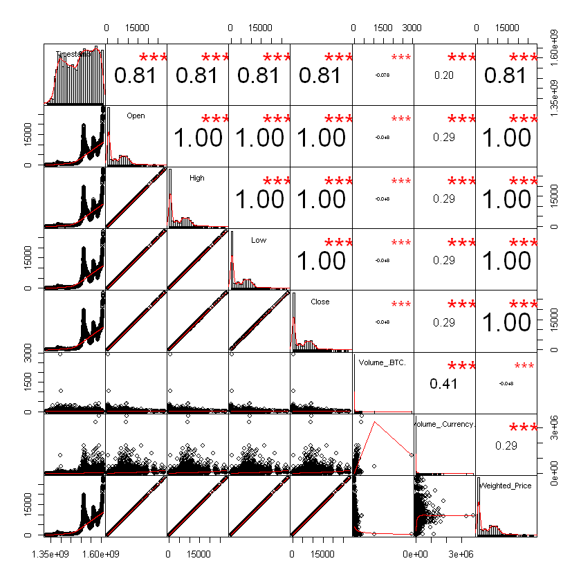

```r
chart.Correlation(bit_value_reduced, histogram=TRUE, pch=3)
```

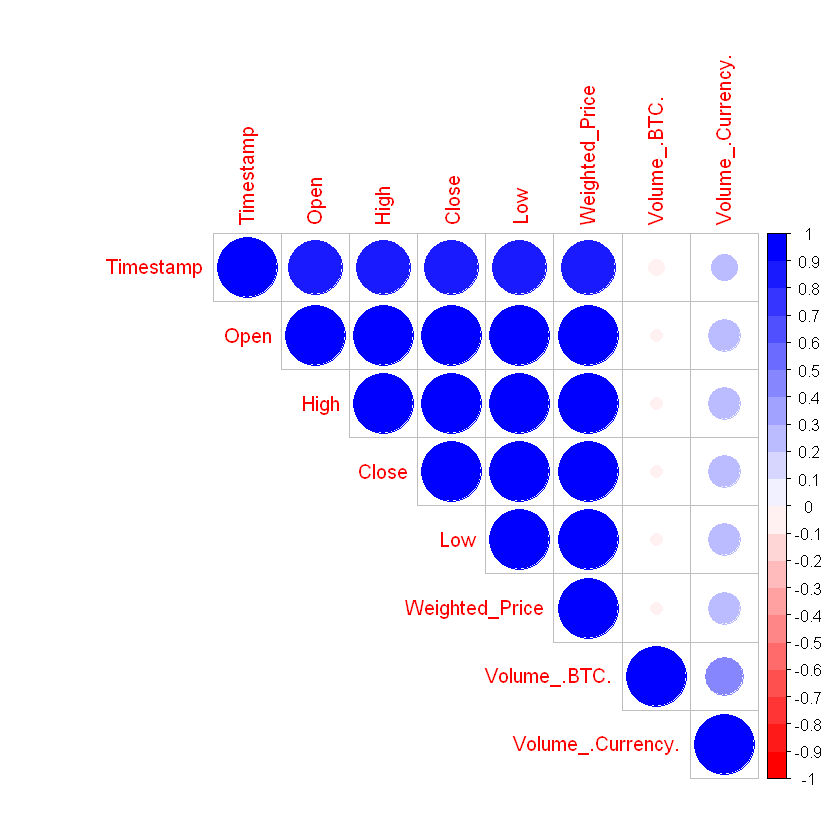

```r
col<- colorRampPalette(c("red", "white", "blue"))(20)
corrplot(cor_mat, method="circle", type="upper", order="hclust", col=col)
```

### The above graphs both confirm what was shown by the correlation matrix, there is little to no correlation between volume traded and daily closing price.

# Step Three: Fitting the models

```r
data_clean <- select(bit_value_reduced, -1)
```

### Next the data will be normalized such that all values are between 0 and 1. (Mulani, 2021)

```r
data_norm <- preProcess(as.data.frame(data_clean), method=c("range"))
```

```r
data_scaled.df <- predict(data_norm, as.data.frame(data_clean))
```

### R does not like parenthesis in column names and so those names will be fixed.

```r
setnames(data_scaled.df, old=c("Volume_.BTC.","Volume_.Currency."), new=c("volume_coin", "volume_currency"))
```

```r
head(data_scaled.df)
```

A data.frame: 6 × 7

|  | Open <dbl> | High <dbl> | Low <dbl> | Close <dbl> | volume_coin <dbl> | volume_currency <dbl> | Weighted_Price <dbl> |
| --- | --- | --- | --- | --- | --- | --- | --- |
| 2620776 | 0.190657602 | 0.190621167 | 0.190717754 | 0.190659752 | 9.026664e-06 | 3.788837e-05 | 0.190722689 |
| 326786 | 0.022555523 | 0.022551213 | 0.022178229 | 0.022454717 | 2.955550e-02 | 1.455415e-02 | 0.022265235 |
| 530477 | 0.021995564 | 0.022065678 | 0.022004342 | 0.022075185 | 2.051797e-03 | 9.990695e-04 | 0.022014057 |
| 804769 | 0.008759361 | 0.008757687 | 0.008750314 | 0.008747653 | 1.290845e-03 | 2.529589e-04 | 0.008758881 |
| 2499962 | 0.122084549 | 0.122111825 | 0.122084734 | 0.122107792 | 1.265007e-03 | 3.395703e-03 | 0.122119970 |
| 295495 | 0.027652143 | 0.027784875 | 0.027667185 | 0.027658771 | 2.818166e-03 | 1.727847e-03 | 0.027762713 |

### The dataset is now fully clean and prepared for use.

### Next a scatterplot of volume traded vs closing price will be created in order to see, in greater detail, if any relationship exists between the variables.

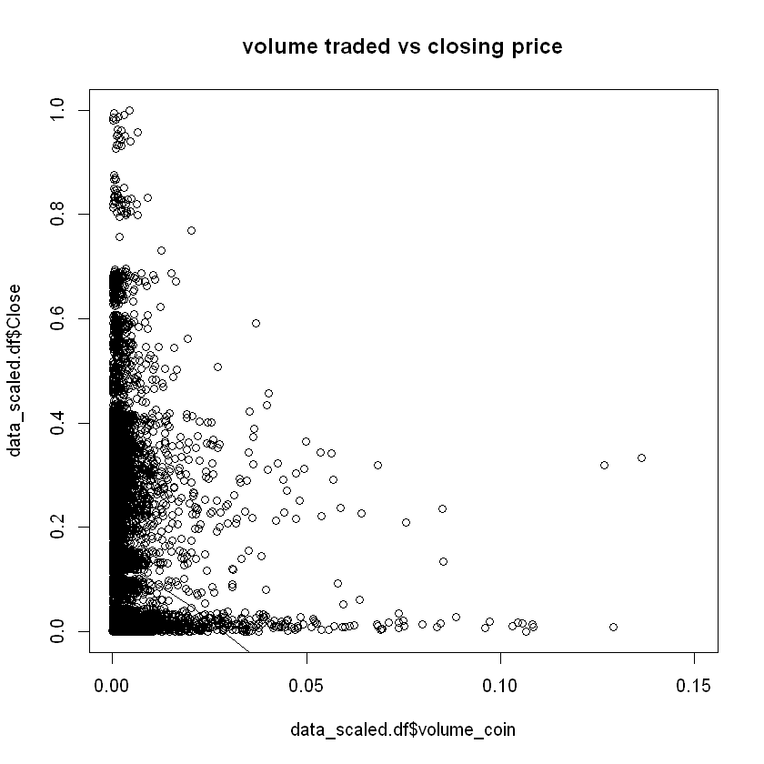

```r
scatter.smooth(x=data_scaled.df$volume_coin, y=data_scaled.df$Close, xlim = c(0,0.15), ylim=c(0,1), main="volume traded vs closing price")
```

### Looking at the graph of closing price versus volume traded, it is clear that no linear relationship exists between the quantities. Even though no linear relationship is apparent in the above graph, a linear model will still be fit to the data as a way to check goodness of fit.

### In the case in which no linear relationship exsits between the variables one approach is to transform one of the variables and then check if a linear relationship exists between the transformed variable and the non-transformed variable. (Log in R - Transforming Your Data, 2019)

```r
data_scaled.df$logvolume=log(data_scaled.df$volume_coin)
```

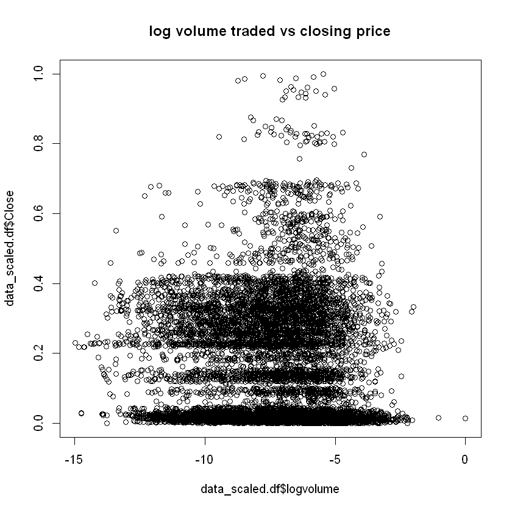

```r
plot(x=data_scaled.df$logvolume, y=data_scaled.df$Close, ylim=c(0,1), main="log volume traded vs closing price")
```

# Creating the Linear Regression model:

### Before a linear model can be fit to the data the assumptions of linear regression must be met. (Zach, 2021)

- Linear relationship: There exists a linear relationship between the independent variable, x, and the dependent variable, y.
- Independence: The residuals are independent. In particular, there is no correlation between consecutive residuals in time series data.
- Homoscedasticity: The residuals have constant variance at every level of x.
- Normality: The residuals of the model are normally distributed.

# Advantages and disadvantages of linear regression (Kumar et al., 2019):

### Advantages

- Linear Regression performs well when the dataset is linearly separable. We can use it to find the nature of the relationship among the variables.
- Linear Regression is easier to implement, interpret and very efficient to train.

### Disadvantages

- Main limitation of Linear Regression is the assumption of linearity between the dependent variable and the independent variables. In the real world, the data is rarely linearly separable. It assumes that there is a straight-line relationship between the dependent and independent variables which is incorrect many times.
- Prone to outliers: Linear regression is very sensitive to outliers (anomalies). So, outliers should be analyzed and removed before applying Linear Regression to the dataset.

### The data will be split into a training and a testing set to allow for testing of the models. (Sharma, 2020)

```r
sample_size = round(nrow(data_scaled.df)*.70)
index <- sample(seq_len(nrow(data_scaled.df)), size = sample_size)
```

```r
train <- data_scaled.df[index, ]
test <- data_scaled.df[-index, ]
```

```r
linearMod_train <- lm(High ~ volume_coin, data=train)
print(linearMod_train)
```

```
Call:
lm(formula = High ~ volume_coin, data = train)

Coefficients:
(Intercept)  volume_coin
     0.1658      -0.5737
```

```r
summary(linearMod_train)
```

```
Call:
lm(formula = High ~ volume_coin, data = train)

Residuals:
     Min       1Q   Median       3Q      Max
-0.16577 -0.14862 -0.04735  0.12427  0.83664

Coefficients:
             Estimate Std. Error t value Pr(>|t|)
(Intercept)  0.165808   0.002104  78.817  < 2e-16 ***
volume_coin -0.573666   0.138454  -4.143 3.46e-05 ***
---
Signif. codes:  0 '***' 0.001 '**' 0.01 '*' 0.05 '.' 0.1 ' ' 1

Residual standard error: 0.1721 on 6998 degrees of freedom
Multiple R-squared:  0.002447,	Adjusted R-squared:  0.002305
F-statistic: 17.17 on 1 and 6998 DF,  p-value: 3.463e-05
```

```r
linearMod_test <- lm(High ~ volume_coin, data=test)
print(linearMod_test)
```

```
Call:
lm(formula = High ~ volume_coin, data = test)

Coefficients:
(Intercept)  volume_coin
     0.1636      -1.1631
```

```r
summary(linearMod_test)
```

```
Call:
lm(formula = High ~ volume_coin, data = test)

Residuals:
     Min       1Q   Median       3Q      Max
-0.16317 -0.14502 -0.06311  0.12574  0.83335

Coefficients:
             Estimate Std. Error t value Pr(>|t|)
(Intercept)  0.163582   0.003301  49.549  < 2e-16 ***
volume_coin -1.163119   0.415236  -2.801  0.00513 **
---
Signif. codes:  0 '***' 0.001 '**' 0.01 '*' 0.05 '.' 0.1 ' ' 1

Residual standard error: 0.1681 on 2998 degrees of freedom
Multiple R-squared:  0.00261,	Adjusted R-squared:  0.002278
F-statistic: 7.846 on 1 and 2998 DF,  p-value: 0.005126
```

```r
tidy(linearMod_train)
```

A tibble: 2 × 5

| term <chr> | estimate <dbl> | std.error <dbl> | statistic <dbl> | p.value <dbl> |
| --- | --- | --- | --- | --- |
| (Intercept) | 0.1658084 | 0.002103727 | 78.816502 | 0.000000e+00 |
| volume_coin | -0.5736662 | 0.138454460 | -4.143357 | 3.462913e-05 |

```r
tidy(linearMod_test)
```

A tibble: 2 × 5

| term <chr> | estimate <dbl> | std.error <dbl> | statistic <dbl> | p.value <dbl> |
| --- | --- | --- | --- | --- |
| (Intercept) | 0.1635821 | 0.003301394 | 49.549404 | 0.0000000 |
| volume_coin | -1.1631185 | 0.415236032 | -2.801102 | 0.0051255 |